# Exponential vs. Gompertz, Beispiel Frankreich

Sebastian Schroen

05 December 2020

### Motivation

Die folgenden Analysen sind durch diesen Tweet motiviert:

> Hier sehen Sie Frankreichs Gesamtfallzahlen als "+".  
> Die rote exponentielle und die grüne S-Kurve wurden beide aus den ersten 17 Punkten geschätzt. Man erkennt:  
> a) Anfangs passen beide Kurven.  
> b) Die grüne Kurve ergibt eine gute Prognose, die rote bewirkt Panik. 1/2 [pic.twitter.com/wSu7LEmAxV](https://t.co/wSu7LEmAxV)

> — Stefan Homburg (@SHomburg) [December 3, 2020](https://twitter.com/SHomburg/status/1334561176152379396?ref_src=twsrc%5Etfw)

### Packages

Folgende R Pakete sind notwendig:

```r
library('coronavirus')
library('tidyverse')
library('lubridate')
library('minpack.lm')
```

Alle Codes sind durch einen Klick auf die Buttons auf der rechten Seite einsehbar.

### Daten

Die verwendeten Daten sind von der Johns Hopkins University, bereitgestellt über das `coronavirus` Paket. Um das Paket nicht täglich zu updaten werden die im [Github Repository](https://github.com/RamiKrispin/coronavirus) hinterlegten Rohdaten verwendet. Der Zeitraum liegt vom 21.10. - 2.12., verwendet werden vermutlich (!) die ab 21.10. **neu** aufgetretenen Fälle.

```r
input_data <- read_csv("https://raw.githubusercontent.com/RamiKrispin/coronavirus/master/csv/coronavirus.csv") %>%
    filter(type =="confirmed") %>%
    group_by(date,country) %>%
    summarise(cases = sum(cases)) %>%
    filter(date >= "2020-10-21" & date <=as.Date("2020-12-02") & country == "France")


  cumulative_cases <- input_data %>%
    group_by(country) %>%
    mutate(cumulative_cases= cumsum(cases))%>% select(-cases)%>%
    spread(country, cumulative_cases, drop = TRUE)

#
# input_data <- read_csv("https://covid.ourworldindata.org/data/owid-covid-data.csv") %>% select(iso_code, date, new_cases_smoothed) %>%
#   filter(iso_code == "FRA") %>%
#   filter(date >= "2020-10-21" & date <="2020-12-02")
#
#
# cumulative_cases <- input_data %>%
#     mutate(cumulative_cases= cumsum(new_cases_smoothed))%>% select(-new_cases_smoothed, -iso_code) %>%
#   rename(France = cumulative_cases)

#Remark: Results with this data are almost identical, this can't be it.
```

Die ersten 17 Tagespunkte fließen in die Parameterschätzung ein, anschließend wird mit diesen Parametern für den restlichen Beobachtungszeitraum fortgeschrieben.

### Exponential Fit

Für den exponentiellen Fit wird die folgende Funktionsgleichung verwendet:

$$a \cdot e^{b \cdot t}+c$$

```r
results_exponential <- cumulative_cases[,1]


  cumulative_cases_for_fit <- cumulative_cases[1:17,]
  t = seq(1:nrow(cumulative_cases_for_fit))



  exp_fit <- function(t, a, b, c){
    a*exp(b*t)+c
  }


    dep_var <- as.matrix(cumulative_cases_for_fit[,2])

    summary_tmp <-   nlsLM(dep_var~  a*exp(b*t) + c ,
                           start = list(a = 10000, b = 0.77, c = 10000),
                           control = nls.lm.control(maxiter = 10000)
    ) %>% summary()
    results_tmp <- summary_tmp$parameters
    a <- results_tmp[1,1]
    b <- results_tmp[2,1]
    c <- results_tmp[3,1]



    t2 = seq(1:43)
    results_exponential$Exponential <- exp_fit(t2,a, b, c)




  print(summary_tmp)
```

```
##
## Formula: dep_var ~ a * exp(b * t) + c
##
## Parameters:
##     Estimate Std. Error t value Pr(>|t|)
## a  1.898e+06  1.231e+06   1.541   0.1456
## b  1.962e-02  1.075e-02   1.826   0.0893 .
## c -1.918e+06  1.245e+06  -1.540   0.1457
## ---
## Signif. codes:  0 '***' 0.001 '**' 0.01 '*' 0.05 '.' 0.1 ' ' 1
##
## Residual standard error: 21050 on 14 degrees of freedom
##
## Number of iterations to convergence: 44
## Achieved convergence tolerance: 1.49e-08
```

### Gompertz Fit

Für die Gompertz-Funktion wird folgende Gleichung verwendet:

$$a \cdot e^{-b \cdot e^{-c \cdot t}}$$

```r
results_gompertz <- cumulative_cases[,1]


  cumulative_cases_for_fit <- cumulative_cases[1:17,]
  t = seq(1:nrow(cumulative_cases_for_fit))



  gompertz_fit <- function(t, a, b, c){
    a*exp(-b*exp(-c*t))
  }



    dep_var <- as.matrix(cumulative_cases_for_fit[,2])

    summary_tmp <-   nlsLM(dep_var~  a*exp(-b*exp(-c*t)),
                           start = list(a = 10, b = 10, c =0.10),
                           control = nls.lm.control(maxiter = 10000)
    ) %>% summary()
    results_tmp <- summary_tmp$parameters
    a <- results_tmp[1,1]
    b <- results_tmp[2,1]
    c <- results_tmp[3,1]



    t2 = seq(1:43)
    results_gompertz$Gompertz <- gompertz_fit(t2,a, b, c)

    print(summary_tmp)
```

```
##
## Formula: dep_var ~ a * exp(-b * exp(-c * t))
##
## Parameters:
##    Estimate Std. Error t value Pr(>|t|)
## a 1.064e+06  1.130e+05   9.409 1.98e-07 ***
## b 3.583e+00  1.782e-01  20.103 1.00e-11 ***
## c 1.289e-01  1.529e-02   8.431 7.39e-07 ***
## ---
## Signif. codes:  0 '***' 0.001 '**' 0.01 '*' 0.05 '.' 0.1 ' ' 1
##
## Residual standard error: 21440 on 14 degrees of freedom
##
## Number of iterations to convergence: 56
## Achieved convergence tolerance: 1.49e-08
```

### Grafischer Vergleich

Folgende Grafik ergibt sich, wenn man die Schätzung mit den oben gennanten Schätzgleichungen extrapoliert und plottet:

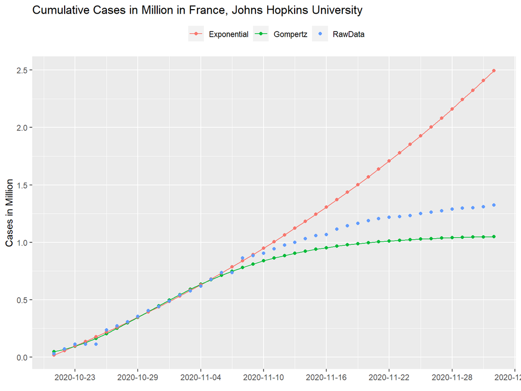

### Exponential Fit ohne Konstante

Offensichtlich passt das nicht zum Ausgangstweet, sodass ich ein bisschen herumprobiert habe, um den Grund für die Unterschiede zu identifizieren. Folgende Schätzgleichung ist die einzige, die die Grafik im Tweet auch nur annähernd repliziert:

$$a \cdot e^{b \cdot t}$$

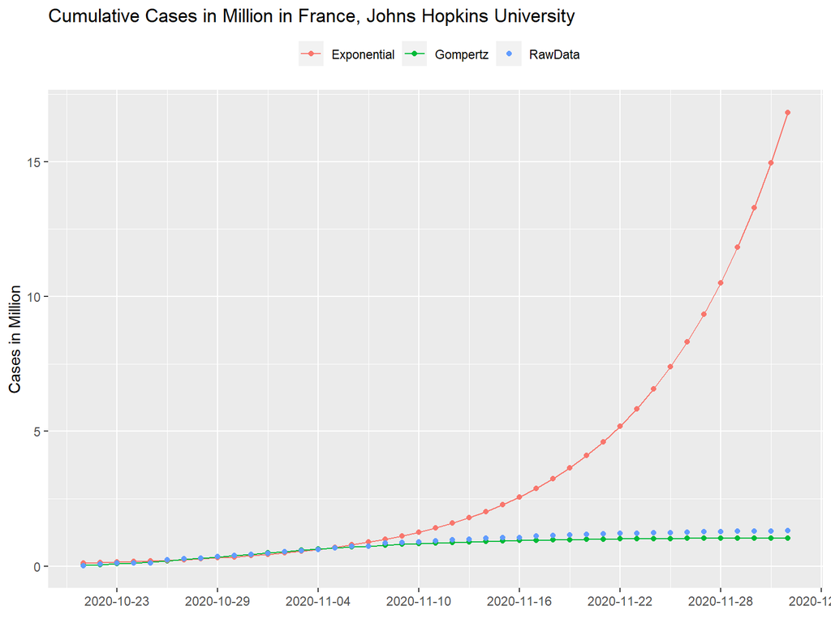

```r
results_exponential2 <- cumulative_cases[,1]


  cumulative_cases_for_fit <- cumulative_cases[1:17,]
  t = seq(1:nrow(cumulative_cases_for_fit))



  exp_fit <- function(t, a, b){
    a*exp(b*t)
  }


    dep_var <- as.matrix(cumulative_cases_for_fit[,2])

    summary_tmp <-   nlsLM(dep_var~  a*exp(b*t) ,
                           start = list(a = 10000, b = 0.77),
                           control = nls.lm.control(maxiter = 10000)
    ) %>% summary()
    results_tmp <- summary_tmp$parameters
    a <- results_tmp[1,1]
    b <- results_tmp[2,1]
   # c <- results_tmp[3,1]



    t2 = seq(1:43)
    results_exponential2$Exponential <- exp_fit(t2,a, b)



data_for_plot_homburg <- left_join(results_gompertz, results_exponential2)%>%
  left_join(cumulative_cases) %>%
  rename(RawData = France) %>%
  pivot_longer(!date, values_to = "Value", names_to = "Fit") %>%
  mutate(Value = Value/10^6)




ggplot(data=data_for_plot_homburg, aes(x=date, y = Value, color = Fit, linetype = Fit)) + geom_line() + geom_point() +
  scale_linetype_manual(values=c("solid", "solid", "blank")) +
  ylab("Cases in Million") +
  xlab(element_blank()) +
   theme(legend.position="top", legend.title = element_blank()) +
  scale_x_date(date_breaks = "6 days") +
  ggtitle("Cumulative Cases in Million in France, Johns Hopkins University")
```

```r
ggsave("France_homburg.png", width = 30, height = 20, units =  "cm")
```

Noch nicht perfekt, aber diese Unterschiede stammen voraussichtlich aus anderen Daten. Dieses Problem ließe sich schnell durch eine Quellenangabe beheben.

### Schätzung mit vollständigen Daten

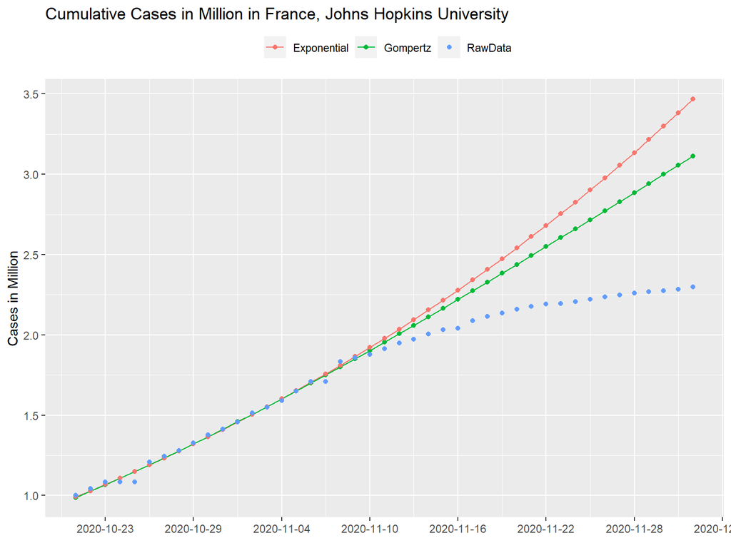